# Extending Excel with R

One day hands on Training

Trainer: Abiyu Giday

# Course Description

[figure not shown]

Extending Excel with R.

MS Excel is one of the most widely used application for working with data. Due to explosion of data volume, requirement to generate frequent reproducible analysis and frequent reporting, Excel can extend its capability by adding R in its workflow. R is a system of statistical computation and graphics, that is widely used to analyze data, generate high quality graphics visualization and model data. “R is freely available under the GNU General Public License”.

This training is a “One full day” training. We have optional “Day two” training with special request.

**To Register :-**

email: abiyu.giday@dataRecode.com

Or

[Fill out the form located here.](https://datarecode.com/HireMe!.html)

# Types of Delivery

- Instructor led in-person training.
- Instructor led online training.

# This training is for you if

- If you use Excel to analyze data and want to automate the process with R
- If you want to improve maximize working with multiple Excel workbooks with R

- If you generate report with Excel and want expand the capability with R/Rmarkdown
- If you want to automate generating high quality graphics from your Excel with R
- If you want to improve data wrangling skills and prepare data for Dashboards feeds

# Learners Outocome

By the end of the course, students will have hands on experience learning :-

- How to Use RStudio IDE basics
- How to import data from Excel to R
- How to selectively import parts of Excel sheet and multiple Excel sheets
- How to import Excel workbook
- How to perform basic data wrangling/carpentry (select/filter/group_by/pivot/reshape and more)
- How to write and store reusable script
- How to create and embed data analysis in word, pdf and html formats
- How to prepare and plot basic data visualization graphics

[figure not shown]

  Self Contained Lab setup

# Learning Materials

- Training document will be made available
- Each student will have his/her own login/passwd account
- All Exercise data will be provided
- All labs will be made available on RStudio server docker image pre loaded with R, tidyverse/readxl. (Students do not need to load R or the R packges required for the class)

# Requirments and Assumptions

- Student is expected to have some Excel Experience.
- No prior experience with R is assumed.
- Student need to come with a laptop (Mac/Win/Linux OS) with wifi and Chrome/Firefox browser.

# Course Organization

**One day training inlcludes**

[figure not shown]

Excel Transformation

## Excel and R the Intro (Parallel)

- High level common Excel tricks and how they are done with R.
- Import Data
- Math/Stats with Excel/R
- Row wise/Column wise with Excel/R
- Variable types (empty/boolean/numeric/text) Excel/R
- Drag and fill and mutate with Excel/R
- Plots (scatter/line/bar/pie) Excel/R

*Excercise/lab: a/b/c/d/e/f*

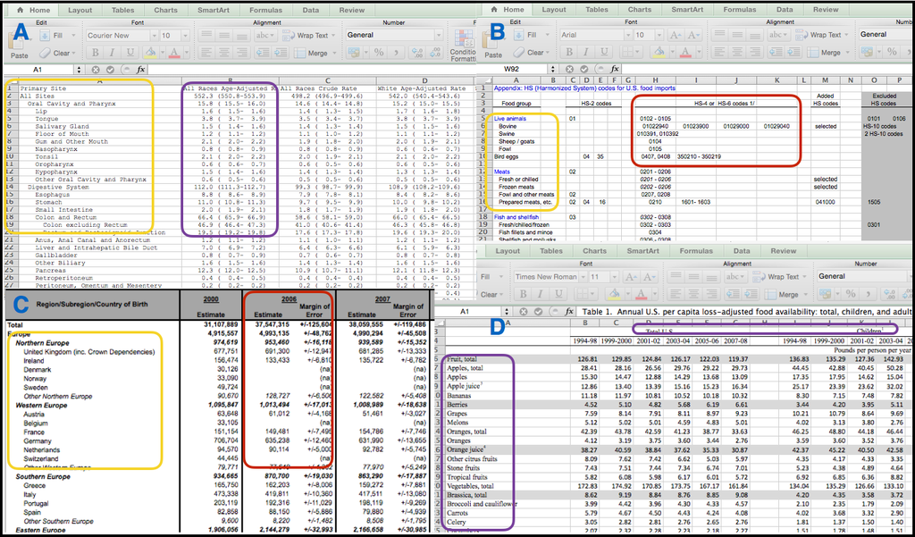

Untidy Sample Excel workbook

## Excel to R - data import (Playing together)

- Now that we see the parallel between Excel & R
- R environs with R studio
- how to import data from Excel worksheet to R
- How to review the structure of the data on R
- Import tricks - skip/n-max/range/mix
- How to import data from Excel Workbook to R

*Excercise/lab: a/b/c/d*

## Excel to R - intermediate (R Extend Excel)

- Intermediate level tips/tools
- Pivot table (group_by/summary)in Excel/R
- Reshape table in Excel/R
- Graphics plot with Excel/R
- Summary Stat Excel/R
- Import data from web
- Table *_joint tables

*Exercise/lab: a/b/c/d/e*

# Optional Day two training will inlclude

- Working together on GIT
- Reproducible report with RMarkdown
- Script multiple workbook/worksheet
- Advanced graphics
- Advanced scripting

# Contact and registration

To get more information, or get a quote send e-mail to abiyu.giday@dataRecode.com or visit the website and fill out the form here: `https://datarecode.com/HireMe!.html`

The training can be tailored to fit your organization requirement.

## About the trainer

[Abiyu Giday background](https://datarecode.com/about.html)

# Excel to R sample readings

This two blogs will give you an overview of the advantages of extending Excel with R.  
1. [Transforming Excel to tidy data](https://datarecode.com/blog.html#blog_3_-_transorming_excel_to_tidy_data)  
2. [Import and Transform Excel data](https://datarecode.com/blog.html#blog_2_-_transform_and_import_excel_data_to_r)

~End